# Лекция 17. Чувствительность и робастность

Блок 5. Честный отчёт

Карен Аванесян

Каузальный анализ в R на данных RLMS-HSE

# Зачем

## Оценка — не ответ

угроза 1

### Непроверяемое допущение

«Нет ненаблюдаемых конфаундеров», «параллельные тренды», «исключение инструмента». Проверить нельзя. Можно спросить: **насколько сильным должно быть нарушение, чтобы вывод изменился?**

угроза 2

### Мы сами

Не данные, а мы: сотни решений по пути (контроли, выборка, форма исхода) и соблазн выбрать «красивую» спецификацию.

угроза 3

### Проверки «на ноль»

Если метод находит эффект там, где его быть не должно, он найдёт его и там, где не должен.

Раздел «Robustness» в хорошей работе — не набор таблиц «результат не изменился», а ответ на три вопроса: какой конфаундер нас сломает, от каких наших решений зависит результат, проходит ли дизайн плацебо.

## Пример занятия

6 698 человек: RLMS 2016, занятые 25–60 лет

0.25 лога: отдача от высшего образования по регрессии

главный пример

### Диплом → зарплата

Контроли — пол, возраст, город, площадка, «Большая пятёрка». Главный подозреваемый — способности, которых нет в данных. Насколько сильными они должны быть?

плюс два коротких

### E-value и Розенбаум

Курение → здоровье (E-value) и обучение → зарплата в мэтчинге (границы Розенбаума).

## План занятия

1. Чувствительность к пропущенной переменной: `sensemakr` и robustness value; как читать вывод и писать результат
2. Границы Остера: движение коэффициента и $R^2$
3. E-value для относительных рисков
4. Границы Розенбаума для мэтчинга
5. Кривая спецификаций: `specr`
6. Плацебо-тесты и чек-лист отчёта

# Идея

## Сила конфаундера в единицах $R^2$

Пусть есть ненаблюдаемый $Z$. Смещение коэффициента при $D$ определяют две величины (Cinelli & Hazlett 2020):

- $R^2_{D \sim Z \mid X}$ — какую долю **остаточной** дисперсии воздействия объясняет $Z$
- $R^2_{Y \sim Z \mid D, X}$ — какую долю остаточной дисперсии исхода объясняет $Z$

$$|\text{bias}| = \text{se}(\hat\tau) \cdot \sqrt{\frac{R^2_{Y \sim Z\mid D,X}\; R^2_{D \sim Z \mid X}}{1 - R^2_{D \sim Z \mid X}}}\cdot\sqrt{df}$$

## Robustness value и бенчмарки

- **Robustness value** RV: если обе доли $R^2$ меньше RV, конфаундер не может обнулить эффект. RV = 0 — результат хрупок, RV = 0.5 — очень прочен. Отдельно считается RV для потери значимости
- **Бенчмарк**: «конфаундер в $k$ раз сильнее пола» — переводит абстрактные $R^2$ в понятные единицы: берём наблюдаемую ковариату и спрашиваем, что будет, если $Z$ связан с $D$ и $Y$ так же сильно (или в $k$ раз сильнее)
- Контурная карта: по осям — две доли $R^2$, линии — скорректированная оценка. Бенчмарки — точки на карте; граница «оценка = 0» — красный пунктир

## Другие языки для того же вопроса

RV, контурная карта

### `sensemakr`

Регрессия, любой исход.

«$Z$ должен быть сильнее пола втрое»

$\delta$, $\beta^*$

### Остер (2019)

Регрессия; отбор по ненаблюдаемым пропорционален отбору по наблюдаемым.

«Ненаблюдаемые должны быть в $\delta$ раз важнее наблюдаемых»

E

### E-value

Относительный риск.

«$Z$ должен поднимать и $D$, и $Y$ в E раз»

$\Gamma$

### Розенбаум

Мэтчинг, парные тесты.

«$Z$ меняет шансы попасть в группу в $\Gamma$ раз»

Все четыре отвечают на один вопрос — **насколько сильный $Z$ нужен**, — но в разных моделях. Выбор определяется дизайном, не вкусом.

## Робастность к нашим решениям

- Garden of forking paths: контроли, выборка, определение исхода, оценка ошибок, выбросы — $2^{10}$ вариантов, из которых в статье один
- **Кривая спецификаций** (Simonsohn, Simmons, Nelson 2020): оценить **все** разумные варианты и показать их распределение, а не лучший
- Важно: «все разумные» — не «все возможные». Спецификации с плохими контролями (лекция 3) или без ключевого конфаундера — не альтернативы, а ошибки, их в кривой быть не должно

## Плацебо-тесты: где эффект должен быть нулём

| Тип | Что проверяем | Где было в курсе |
| --- | --- | --- |
| Предтренды | эффект до воздействия | event study (л. 8), DiD (л. 9–10) |
| Плацебо-порог | скачок там, где нет правила | RD (л. 11) |
| Плацебо-исход | эффект на переменную, которую $D$ трогать не может | баланс ковариат (л. 2, 5, 11) |
| Плацебо-группа | эффект у тех, кого реформа не касалась | пенсионная реформа (л. 9, 10) |
| Плацебо-инструмент | reduced form в подвыборке, где first stage = 0 | IV (л. 12) |

Плацебо не доказывает дизайн, но его провал — почти всегда приговор. Хороший плацебо-тест **имеет шанс провалиться**: «эффект на пол» не проверяет ничего.

# Код

## `sensemakr`: карта чувствительности

- Результат
- Код

```
Sensitivity Analysis to Unobserved Confounding

Model Formula: log_wage ~ higher_ed + female + age + age2 + urban + site + O +
    C + E + A + ES

Null hypothesis: q = 1 and reduce = TRUE

Unadjusted Estimates of ' higher_ed ':
  Coef. estimate: 0.254
  Standard Error: 0.017
  t-value: 14.8

Sensitivity Statistics:
  Partial R2 of treatment with outcome: 0.032
  Robustness Value, q = 1 : 0.166
  Robustness Value, q = 1 alpha = 0.05 : 0.146

For more information, check summary.
```

```r
m <- lm(log_wage ~ higher_ed + female + age + age2 + urban + site + O + C + E + A + ES, d)
s <- sensemakr(m, treatment = "higher_ed", benchmark_covariates = c("female", "C"),
               kd = 1:3, ky = 1:3)         # Z в 1, 2, 3 раза сильнее пола / добросовестности
s
```

## Как читать вывод `summary(sensemakr)`

- Вывод R
- С пояснениями

```
Null hypothesis: q = 1 and reduce = TRUE
Unadjusted Estimates of 'higher_ed':
  Coef. estimate: 0.254
  Standard Error: 0.017
  t-value (H0:tau = 0): 14.8
Sensitivity Statistics:
  Partial R2 of treatment with outcome: 0.032
  Robustness Value, q = 1: 0.166
  Robustness Value, q = 1, alpha = 0.05: 0.146
```

| bound_label | r2dz.x | r2yz.dx | adj_est | adj_lo | adj_hi |
| --- | --- | --- | --- | --- | --- |
| 1x female | 0.018 | 0.111 | 0.191 | 0.159 | 0.223 |
| 2x female | 0.036 | 0.221 | 0.126 | 0.096 | 0.157 |
| 3x female | 0.054 | 0.332 | 0.061 | 0.033 | 0.089 |
| 1x C | 0.001 | 0.003 | 0.252 | 0.218 | 0.286 |
| 2x C | 0.001 | 0.006 | 0.250 | 0.217 | 0.284 |
| 3x C | 0.002 | 0.009 | 0.248 | 0.215 | 0.282 |

1 · шапка

`q = 1, reduce = TRUE`: ищем смещение, которое уменьшает оценку на 100 %, до нуля. `Unadjusted` — исходная регрессия: 0.254 (t = 14.8)

2 · Partial R²

0.032 — доля остаточной дисперсии зарплаты, объяснённая дипломом. Крайний $Z$, объясняющий **всю** остаточную дисперсию зарплаты, должен объяснять ≥ 3.2 % дисперсии диплома

3 · RV, q = 1

0.166: $Z$, объясняющий ≥ 16.6 % остаточной дисперсии **и** диплома, **и** зарплаты, обнуляет оценку; более слабый — нет

4 · RV, alpha = 0.05

0.146: порог, после которого эффект перестаёт быть значимым на 5 %. Всегда ниже RV для нуля

5 · таблица границ

`1x female`: $Z$, связанный с дипломом и зарплатой как пол ($R^2$ = 0.018 и 0.111), даёт оценку 0.191 [0.159; 0.223]

6 · сигналы беды

RV ниже $R^2$ правдоподобного бенчмарка; бенчмарк выбран слабым («как `C`» — всегда прочно); интервал при 1× бенчмарке включает 0

## Контурная карта

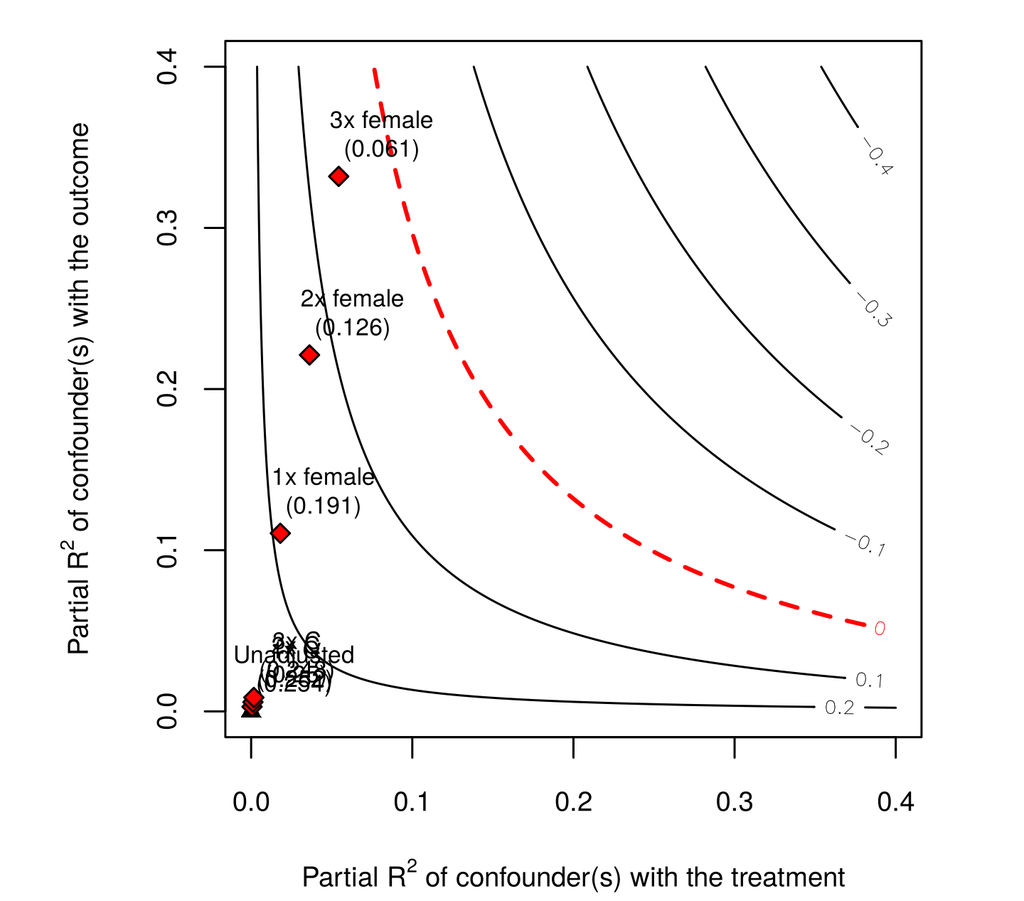

```r
plot(s, lim = 0.4)
```

## Что говорит карта

- RV ≈ 17%: чтобы обнулить эффект, $Z$ должен объяснять 17% остаточной дисперсии **и** диплома, и зарплаты. Для статистической значимости — 15%
- Бенчмарки: конфаундер «как пол» (1× female) снижает оценку с 0.25 до 0.19; втрое сильнее пола — до 0.06, но всё ещё > 0. Добросовестность как бенчмарк — почти ничего: черты личности слабо связаны с дипломом при данных контролях
- Вопрос к теории: могут ли «способности» быть втрое сильнее пола и как предиктор диплома, и как предиктор зарплаты? Пол объясняет 11% остаточной дисперсии зарплаты — высокая планка

## Как писать результат

шаблон

«Оценка отдачи от высшего образования — 0.254 лога (s.e. 0.017) — устойчива к умеренному ненаблюдаемому конфаундингу: чтобы обнулить её, конфаундер должен объяснять не менее 16.6 % остаточной дисперсии и диплома, и зарплаты; для потери значимости на 5 % — 14.6 %. Конфаундер, связанный с дипломом и зарплатой так же сильно, как пол, снизил бы оценку до 0.191 (95 % ДИ [0.159; 0.223]), втрое более сильный — до 0.061.»

- Обязательно: бенчмарк и довод, почему главный $Z$ (способности) **не сильнее** его; RV и для нуля, и для значимости
- Не писать «результат робастен» без условия: RV без бенчмарка ни о чём не говорит

## Границы Остера: движение коэффициента

Идея: если добавление наблюдаемых контролей сдвинуло коэффициент мало, а $R^2$ — сильно, ненаблюдаемые вряд ли переломят результат. $\delta$ — во сколько раз отбор по ненаблюдаемым должен быть сильнее отбора по наблюдаемым, чтобы $\beta = 0$; $R^2_{\max}$ обычно $1.3 \times R^2$.

```r
ctrl <- "female + age + age2 + urban + site + O + C + E + A + ES"
od <- o_delta(y = "log_wage", x = "higher_ed", con = ctrl, R2max = 1.3 * summary(m)$r.squared,
              type = "lm", data = d)
od
```

| Name | Value |
| --- | --- |
| delta* | 6.978 |
| Uncontrolled Coefficient | 0.305 |
| Controlled Coefficient | 0.254 |
| Uncontrolled R-square | 0.038 |
| Controlled R-square | 0.298 |
| Max R-square | 0.388 |
| beta hat | 0.000 |

## Как читать вывод `o_delta()` и `o_beta()`

- Вывод R
- С пояснениями

```r
ob <- o_beta(y = "log_wage", x = "higher_ed", con = ctrl, delta = 1,
             R2max = 1.3 * summary(m)$r.squared, type = "lm", data = d)
head(ob, 4)
```

| Name | Value |
| --- | --- |
| beta* | 0.233 |
| (beta*-beta controlled)^2 | 0.000 |
| Alternative Solution 1 | 12.464 |
| (beta[AS1]-beta controlled)^2 | 149.089 |

1 · `delta*`

6.98: во сколько раз отбор по ненаблюдаемым должен быть сильнее отбора по наблюдаемым, чтобы $\beta = 0$. По Остеру $|\delta| > 1$ — «прочно»

2 · коэффициенты и $R^2$

`Uncontrolled` → `Controlled`: 0.305 → 0.254; $R^2$: 0.038 → 0.298. Остер смотрит на **оба** движения

3 · `Max R-square`

0.388 = 1.3 × $R^2$ с контролями (правило Остера). $\delta^*$ и $\beta^*$ сильно зависят от этого выбора — покажите несколько

4 · `beta*`

0.233 — оценка при $\delta = 1$: если ненаблюдаемые так же важны, как наблюдаемые

5 · `Alternative Solution 1`

Второй корень уравнения Остера (12.5). Берётся корень, ближайший к оценке с контролями, — см. квадраты расстояний

6 · сигналы беды

Контроли слабо связаны с дипломом: коэффициент почти не двигается, и высокий $\delta$ достаётся «даром» — главного (способностей) мы не наблюдаем

## E-value: курение и плохое здоровье

```r
h <- rlms |> filter(year == 2016, age >= 25, age <= 60, !is.na(smokes), !is.na(poor_health))
g <- feglm(poor_health ~ smokes + female + age + I(age^2) + urban + higher_ed | site_code,
           h, family = "poisson", vcov = "hetero")      # пуассон с робастными ошибками = RR
ct <- coeftable(g)["smokes", ]
rr <- exp(ct[1]); ci <- exp(ct[1] + c(-1.96, 1.96) * ct[2])
evalues.RR(rr, ci[1], ci[2])
```

```
         point lower upper
RR        1.27  1.06  1.52
E-values  1.85  1.30    NA
```

- Курильщики сообщают о плохом здоровье в 1.27 раза чаще. E-value = 1.85: чтобы объяснить это без причинности, $Z$ должен повышать и шанс курить, и шанс плохого здоровья **минимум** в 1.85 раза; для границы интервала — в 1.3 раза
- 1.3 — немного: образование, доход, стресс легко дают такую связь. Результат хрупок

## Границы Розенбаума для мэтчинга

Мэтчинг 1:1 по тем же контролям, пары «диплом — без диплома». Тест Уилкоксона по парам при разных $\Gamma$ — отношении шансов иметь диплом из-за скрытого фактора:

```r
m_nn <- matchit(higher_ed ~ female + age + age2 + urban + site + O + C + E + A + ES, data = d,
                method = "nearest", caliper = 0.1, ratio = 1)
pairs <- match.data(m_nn) |> select(subclass, higher_ed, log_wage) |>
  pivot_wider(names_from = higher_ed, values_from = log_wage, names_prefix = "y")
psens(pairs$y1, pairs$y0, Gamma = 2.5, GammaInc = 0.25)
```

## Границы Розенбаума для мэтчинга

```
 Rosenbaum Sensitivity Test for Wilcoxon Signed Rank P-Value

Unconfounded estimate ....  0

 Gamma Lower bound Upper bound
  1.00           0      0.0000
  1.25           0      0.0000
  1.50           0      0.0000
  1.75           0      0.0396
  2.00           0      0.7888
  2.25           0      0.9989
  2.50           0      1.0000

 Note: Gamma is Odds of Differential Assignment To
 Treatment Due to Unobserved Factors
```

## Оценка Ходжеса–Лемана при разных $\Gamma$

```r
hlsens(pairs$y1, pairs$y0, Gamma = 2, GammaInc = 0.5)
```

```
 Rosenbaum Sensitivity Test for Hodges-Lehmann Point Estimate

Unconfounded estimate ....  0.265

 Gamma Lower bound Upper bound
   1.0      0.2653       0.265
   1.5      0.0653       0.465
   2.0     -0.0347       0.565

 Note: Gamma is Odds of Differential Assignment To
 Treatment Due to Unobserved Factors
```

## Кривая спецификаций

```r
sp <- setup(data = d, x = "higher_ed", y = c("log_wage", "log_hwage"), model = "lm",
            controls = c("female", "age + age2", "urban", "site", "O + C + E + A + ES"),
            subsets = list(female = unique(d$female), urban = unique(d$urban)))
res <- specr(sp)
nrow(res$data)                                          # число спецификаций
```

```
[1] 576
```

Два исхода (месячная и часовая зарплата) × 32 набора контролей × 9 подвыборок = 576 регрессий за 10 секунд.

## Что показывает кривая

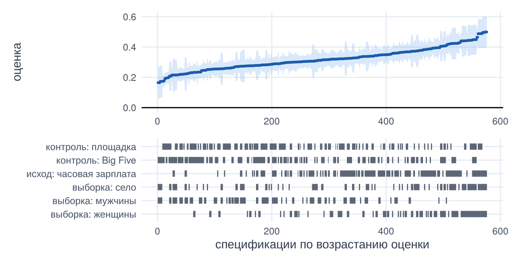

## Чтение кривой

- Итог
- Код и таблица

576 спецификаций

0.17–0.50 размах оценок

0.315 медиана

100% доля значимых

```r
res$data |> summarise(min = min(estimate), медиана = median(estimate), max = max(estimate),
                      `доля значимых` = mean(conf.low > 0)) |>
  mutate(across(everything(), \(x) round(x, 3)))
```

| min | медиана | max | доля значимых |
| --- | --- | --- | --- |
| 0.165 | 0.315 | 0.499 | 1 |

## Плацебо-исход

Если регрессия ловит способности, а не диплом, она найдёт «эффект диплома» и на то, что диплом вызвать не может — например, на черты личности, если они стабильны:

```r
map_dfr(c("O", "C", "E", "A", "ES"), \(v) {
  f <- as.formula(paste(v, "~ higher_ed + female + age + age2 + urban + site"))
  tidy(feols(f, d, vcov = "hetero")) |> filter(term == "higher_ed") |> mutate(черта = v)
}) |> transmute(черта, оценка = round(estimate, 3), se = round(std.error, 3)) |> t()
```

```
       [,1]    [,2]    [,3]    [,4]    [,5]
черта  "O"     "C"     "E"     "A"     "ES"
оценка "0.334" "0.134" "0.069" "0.096" "0.099"
se     "0.023" "0.023" "0.026" "0.025" "0.026"
```

- Диплом «влияет» на открытость (0.33 SD) и добросовестность (0.13 SD): либо учёба меняет личность, либо отбор в вуз идёт по чертам — тогда они конфаундеры, а не плацебо
- Провал полезен: контролировать за O и C нужно, и наверняка остаются черты, которых в данных нет

# Как ошибаются

## Семь ошибок с робастностью

1. «Робастен» = «не изменился в пяти спецификациях, которые выбрал я»
2. Чувствительность без бенчмарка: RV = 0.17 ни о чём не говорит без сравнения
3. $\delta$ Остера при контролях, слабо связанных с $D$: высокий $\delta$ — артефакт
4. E-value без интервала: для точечной оценки E всегда убедительнее
5. Кривая спецификаций с «плохими контролями» внутри
6. Плацебо, которое не могло провалиться; или провал как «побочный результат»
7. Чувствительность к $Z$ там, где проблема в дизайне: RV не спасёт DiD без параллельных трендов

## Чек-лист раздела «Робастность»

- Главное допущение названо; указано, **какой** $Z$ его нарушил бы
- Чувствительность в единицах, понятных читателю (бенчмарк-ковариата, $\Gamma$, E)
- Интервал, а не только точка
- Перечень решений исследователя и кривая по тем, что обоснованно варьируются
- Хотя бы один плацебо-тест, который мог провалиться
- Вывод содержит условие: «эффект X при условии, что нет $Z$ сильнее, чем …»

# Мини-задача

## Задание к следующему занятию

1. Для вашего проектного эффекта постройте `sensemakr` с двумя бенчмарками и напишите одно предложение для статьи по образцу с занятия
2. Повторите кривую спецификаций для эффекта **обучения** на зарплату (данные лекции 5–6): контроли, подвыборки, прошлая зарплата в контролях / нет. Какая доля спецификаций значима? Что из этого — «плохие контроли»?
3. Для DiD по пенсионной реформе (лекция 9) придумайте плацебо-группу и плацебо-период; оцените оба
4. Объясните в абзаце, почему высокий $\delta$ Остера для отдачи от образования — не повод для спокойствия

# Литература

## Что прочитать

- Cinelli C., Hazlett C. (2020). Making Sense of Sensitivity: Extending Omitted Variable Bias. *JRSS-B* + виньетка `sensemakr`
- Oster E. (2019). Unobservable Selection and Coefficient Stability. *JBES*
- VanderWeele T., Ding P. (2017). Sensitivity Analysis in Observational Research: Introducing the E-Value. *Annals of Internal Medicine*
- Rosenbaum P. *Observation and Experiment* (2017), гл. 9 — границы $\Gamma$ без формул
- Simonsohn U., Simmons J., Nelson L. (2020). Specification Curve Analysis. *Nature Human Behaviour*
- Eggers A., Tuñón G., Dafoe A. (2024). Placebo Tests for Causal Inference. *AJPS*

Каузальный анализ в R · RLMS-HSE · К. Аванесян

← К программе курса